# Pertemuan 2: Eksplorasi Data Titik

Author

Atikah Maulina

# **Bagian 1: Reproduksi Praktikum 2**

# **Analisis Eksplorasi Data Point Pattern**

**Data titik** adalah representasi objek spasial berdimensi nol yang menyatakan lokasi suatu kejadian atau entitas dalam ruang koordinat (x, y), di mana kumpulan titik-titik tersebut membentuk pola sebaran (point pattern) yang dapat dianalisis secara statistik untuk mengidentifikasi karakteristik distribusi spasialnya — seperti clustering, dispersi, atau keacakan (CSR).

**Contoh fenomena** yang dapat direpresentasikan sebagai data titik antara lain:

- Lokasi pohon atau tanaman
- Titik panas dan titik kebakaran hutan
- Lokasi penderita suatu penyakit
- Lokasi kejadian kriminal
- Titik sekolah, rumah sakit, minimarket
- Titik epicentrum gempa bumi
- dsb.

**Ada tiga pola titik:**

1. **Random (Acak)** : setiap titik mempunyai peluang yang sama untuk menduduki suatu ruang dan tidak dipengaruhi oleh titik yang lain
2. **Regular/Uniform** : Titik-titik tersebar dengan jarak yang relatif merata, sehingga cenderung saling menjauh
3. **Agregated/Cluster (bergerombol)** : Banyak titik terkonsentrasi menduduki pada ruang yang sama, dan ruang yang lain sangat sedikit ditempati oleh titik

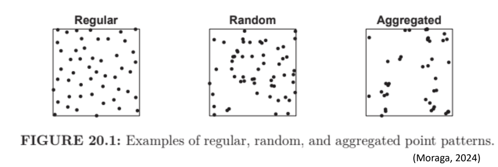

# **Identifikasi Pola Titik**

Identifikasi pola titik spasial dapat dilakukan dengan berbagai pendekatan.  
Beberapa metode yang umum digunakan adalah **metode kuadran** , **Empirical K-Function (Ripley’s K Function)** dan **Kernel Density Estimator (KDE).**  
Ketiga metode ini memiliki keunggulan masing-masing dalam mendeteksi apakah pola titik cenderung **acak, seragam, atau mengelompok**.

## **1. Metode Kuadran**

Metode ini sederhana namun cukup efektif untuk memperoleh gambaran awal apakah titik-titik tersebar secara **acak, seragam, atau mengelompok**.

Langkah-langkah metode kuadran adalah:

1. **Membagi daerah studi** menjadi beberapa sel dengan ukuran yang sama. Ukuran sel ditentukan berdasarkan skala yang diinginkan.
2. **Menghitung rata-rata** banyaknya titik per sel.
3. **Menghitung ragam (variance)** banyaknya titik per sel.
4. **Menghitung perbandingan ragam dengan rata-rata (Variance-to-Mean Ratio / VMR)**

$$\overline{x} = \frac{N}{m} \quad , \quad S^2 = \frac{\sum_{i=1}^m (x_i - \overline{x})^2}{m - 1} \quad , \quad VMR = \frac{S^2}{\overline{x}}$$

$$\begin{aligned} N &= \text{banyaknya titik} \\ m &= \text{banyaknya sel} \\ x_i &= \text{banyaknya titik dalam sel i} \\ \overline{x} &= \text{rata-rata banyaknya titik persel} \\ S^2 &= \text{ragam banyaknya titik persel} \\ VMR &= \text{perbandingan ragam dengan rata-rata} \end{aligned}$$

Keterangan Interpretasi nilai **Variance-to-Mean Ratio (VMR)** adalah sebagai berikut:  
- **VMR = 0** → Titik menyebar seragam (*uniform / sistematik*)  
- **VMR = 1** → Titik menyebar secara acak/random  
- **VMR > 1** → Titik cenderung mengelompok (*clustered*)

### **Hipotesis**

**H0**: Titik menyebar acak

**H1**: Titik tidak menyebar acak

### **Statistik Uji Kuadran**

Metode kuadran digunakan untuk menguji pola titik spasial dengan membagi area pengamatan menjadi sejumlah sel (kuadran). Statistik uji yang digunakan bergantung pada jumlah sel (m):

**Jika (m<30)**

Didekati dengan sebaran Khi-Kuadrat:

$$\chi^2 = (m - 1)VMR = \frac{(m - 1)S^2}{\overline{x}}$$

**Jika (m>=30)**

Didekati dengan sebaran Z:

$$Z = \frac{(m - 1)(VMR - (m - 1))}{\sqrt{2(m - 1)}} = \sqrt{\frac{m - 1}{2}}(VMR - 1)$$

**Keputusan**

- Jika $(\alpha = 5\%, ; Z > 1.96) \rightarrow$ Tolak $(H_0)$ dan terima $(H_1)$ dengan kesimpulan **Kluster**
- Jika $(\alpha = 5\%, ; Z < -1.96) \rightarrow$ Tolak $(H_0)$ dan terima $(H_1)$ dengan kesimpulan **Uniform**

### **Aplikasi pada R**

Sebagai ilustrasi, berikut digunakan dataset **swedishpines** dari paket `spatstat`. Dataset ini sering digunakan untuk contoh analisis pola titik spasial karena bentuknya sederhana namun tetap merepresentasikan fenomena nyata di lapangan.

**Deskripsi**: Data ini memberikan lokasi anakan/biji pohon pinus di sebuah hutan di Swedia.

**Penggunaan** : `data(swedishpines)`

**Format**: Sebuah objek berkelas `"ppp"`*(Planar Point Pattern*) yang merepresentasikan pola titik dari lokasi pohon dalam plot persegi panjang berukuran 9.6×10 meter.

**Planar point pattern** adalah **pola titik yang terletak pada bidang datar dua dimensi (2D plane)** yaitu kumpulan lokasi kejadian yang koordinatnya dinyatakan dalam sistem (x, y) pada ruang Euclidean datar, bukan pada permukaan bumi yang melengkung.

## **Libraries**

```r
knitr::opts_chunk$set(warning = FALSE, message = FALSE)
```

```r
library(spatstat)
data(swedishpines)
```

## **Eksplorasi Data**

```r
X <- swedishpines
plot(X, main = "Swedishpines")
axis(1)
axis(2)
```

[figure not shown]

## **Ringkasan Data**

```r
summary(X)
```

```
Planar point pattern:  71 points
Average intensity 0.007395833 points per square unit (one unit = 0.1 metres)

Coordinates are integers
i.e. rounded to the nearest unit (one unit = 0.1 metres)

Window: rectangle = [0, 96] x [0, 100] units
Window area = 9600 square units
Unit of length: 0.1 metres
```

Dalam analisis pola titik spasial, fungsi **`quadratcount()`** dari paket `spatstat` digunakan untuk membagi **jendela pengamatan (window)** menjadi grid berbentuk **nx × ny kuadrat** dengan ukuran yang sama. Setelah grid terbentuk, fungsi ini akan **menghitung jumlah titik** yang jatuh ke dalam masing-masing kuadrat.

Dengan cara ini, kita dapat mengevaluasi variasi distribusi titik di seluruh area studi. Hasil perhitungan dapat dijadikan dasar untuk analisis lebih lanjut, misalnya menghitung **VMR (Variance-to-Mean Ratio)** untuk menguji pola sebaran titik.

```r
q <- quadratcount(X, nx = 4, ny = 3)
q
```

```
             x
y             [0,24] (24,48] (48,72] (72,96]
  (66.7,100]       7       3       6       5
  (33.3,66.7]      5       9       7       7
  [0,33.3]         4       3       6       9
```

```r
plot(X)
axis(1)
axis(2)
plot(q, add = TRUE, cex = 1.5)
```

[figure not shown]

```r
mu <- mean(q)
sigma <- sd(q)^2
VMR <- sigma/mu
VMR
```

```
[1] 0.6901408
```

Nilai **VMR = 0.690** pada contoh sebelumnya memberikan indikasi awal bahwa titik-titik cenderung menyebar **seragam (uniform)**. Namun, untuk memastikan hal ini secara statistik, kita dapat menggunakan fungsi **`quadrat.test()`** dari paket `spatstat`.

### **Hipotesis Alternatif**

- `alternative = "two.sided"`
  - **H0** : Titik menyebar acak
  - **H1** : Titik tidak acak (bisa uniform atau cluster)
- `alternative = "regular"`
  - **H0** : Titik menyebar acak atau cluster
  - **H1** : Titik menyebar seragam (uniform)
- `alternative = "clustered"`
  - **H0** : Titik menyebar acak atau uniform
  - **H1** : Titik menyebar mengelompok (cluster)

### **Metode Uji**

Secara default, `quadrat.test()` menggunakan pendekatan **Chi-Square test** (`method = "Chisq"`).  
Namun, dapat juga dilakukan uji berbasis **Monte Carlo** (`method = "MonteCarlo"`) untuk hasil yang lebih robust, terutama pada data dengan ukuran sampel kecil.

```r
quadrat.test(q)
```

```
    Chi-squared test of CSR using quadrat counts

data:
X2 = 7.5915, df = 11, p-value = 0.5013
alternative hypothesis: two.sided

Quadrats: 4 by 3 grid of tiles
```

Nilai *p-value* sebesar 0.5013 > 0.05 sehingga H₀ tidak ditolak. Dengan demikian, pola persebaran titik **tidak berbeda secara signifikan dari pola acak (CSR)** pada wilayah pengamatan.

```r
quadrat.test(q, alt = "regular")
```

```
    Chi-squared test of CSR using quadrat counts

data:
X2 = 7.5915, df = 11, p-value = 0.2506
alternative hypothesis: regular

Quadrats: 4 by 3 grid of tiles
```

Nilai *p-value* sebesar 0.2506 > 0.05 sehingga H₀ tidak ditolak. Dengan demikian, **tidak terdapat bukti yang cukup bahwa pola persebaran titik bersifat teratur (regular)** pada wilayah pengamatan.

```r
quadrat.test(q, alt = "clustered")
```

```
    Chi-squared test of CSR using quadrat counts

data:
X2 = 7.5915, df = 11, p-value = 0.7494
alternative hypothesis: clustered

Quadrats: 4 by 3 grid of tiles
```

Nilai *p-value* sebesar 0.7494 > 0.05 sehingga H₀ tidak ditolak. Dengan demikian, **tidak terdapat bukti yang cukup bahwa pola persebaran titik bersifat mengelompok (clustered)** pada wilayah pengamatan.

## **2. Kernel Density Estimation (KDE)**

```r
den <- density(x = X, sigma = 10) # bandwith summary(den)
```

**Sigma** adalah **bandwidth** parameter yang mengontrol **seberapa lebar/halus** kernel yang digunakan untuk “menyebarkan” pengaruh setiap titik ke area sekitarnya.

```r
plot(den, main = "Intensity")
contour(den, add = TRUE) # contour plot
```

[figure not shown]

Pola ini mengindikasikan bahwa sebaran pohon pinus **tidak merata (heterogen)** di seluruh area studi, dengan kecenderungan **mengelompok (clustered)** pada beberapa lokasi spesifik

## **3. Empirical K-Function**

[figure not shown]

**Fungsi K (Ripley’s K Function)** merupakan salah satu alat eksplorasi penting dalam analisis pola titik spasial. Fungsi ini digunakan untuk menilai tingkat ketergantungan antar lokasi pada berbagai jarak.

Secara intuitif, Fungsi K menghitung jumlah rata-rata titik lain yang berada dalam radius dari sebuah titik, kemudian membandingkannya dengan ekspektasi apabila pola sebaran mengikuti **Complete Spatial Randomness (CSR)**.

### **Interpretasi**

- Jika kurva K(r) **mendekati garis CSR** → pola titik acak.
- Jika kurva K(r) **berada di atas garis CSR** → pola cenderung mengelompok (*clustered*).
- Jika kurva K(r) **berada di bawah garis CSR** → pola cenderung seragam (*regular/uniform*).

Misal **contoh data** yang membentuk pola selain acak/random adalah dataset `longleaf.`

```r
nn <- nndist(longleaf)
hist(nn)
```

[figure not shown]

```r
K<- Kest(longleaf, correction="Ripley")
plot(K)
```

[figure not shown]

```r
Z<-envelope(longleaf,Kest, nsim=99)
```

```
Generating 99 simulated realisations of CSR  ...
1, 2, 3, 4, 5, 6, 7, 8, 9, 10, 11, 12, 13, 14, 15, 16, 17, 18, 19, 20,
21, 22, 23, 24, 25, 26, 27, 28, 29, 30, 31, 32, 33, 34, 35, 36, 37, 38, 39, 40,
41, 42, 43, 44, 45, 46, 47, 48, 49, 50, 51, 52, 53, 54, 55, 56, 57, 58, 59, 60,
61, 62, 63, 64, 65, 66, 67, 68, 69, 70, 71, 72, 73, 74, 75, 76, 77, 78, 79, 80,
81, 82, 83, 84, 85, 86, 87, 88, 89, 90, 91, 92, 93, 94, 95, 96, 97, 98,
99.

Done.
```

```r
plot(Z)
```

[figure not shown]

`mad.test()` adalah fungsi di package **spatstat** untuk melakukan **Monte Carlo test**menggunakan **MAD (Maximum Absolute Deviation)** - biasanya dipakai untuk menguji apakah pola titik sesuai dengan **CSR (Complete Spatial Randomness)** atau model tertentu.

**Hipotesis**:

- `alternative = "two.sided"` menguji 𝐻0: Titik menyebar acak vs 𝐻1: Titik tidak menyebar acak (uniform atau kluster)
- `alternative = "less"` menguji 𝐻0: Titik menyebar acak atau kluster vs 𝐻1: Titik menyebar uniform
- `alternative = "greater"` menguji 𝐻0: Titik menyebar acak atau uniform vs 𝐻1: Titik menyebar kluster

```r
mad.test(longleaf, Kest, nsim=99, alternative="two.sided")
```

```
Generating 99 simulated realisations of CSR  ...
1, 2, 3, 4, 5, 6, 7, 8, 9, 10, 11, 12, 13, 14, 15, 16, 17, 18, 19, 20,
21, 22, 23, 24, 25, 26, 27, 28, 29, 30, 31, 32, 33, 34, 35, 36, 37, 38, 39, 40,
41, 42, 43, 44, 45, 46, 47, 48, 49, 50, 51, 52, 53, 54, 55, 56, 57, 58, 59, 60,
61, 62, 63, 64, 65, 66, 67, 68, 69, 70, 71, 72, 73, 74, 75, 76, 77, 78, 79, 80,
81, 82, 83, 84, 85, 86, 87, 88, 89, 90, 91, 92, 93, 94, 95, 96, 97, 98,
99.

Done.
```

```
    Maximum absolute deviation test of CSR
    Monte Carlo test based on 99 simulations
    Summary function: K(r)
    Reference function: theoretical
    Alternative: two.sided
    Interval of distance values: [0, 50] metres
    Test statistic: Maximum absolute deviation
    Deviation = observed minus theoretical

data:  longleaf
mad = 1020.7, rank = 1, p-value = 0.01
```

# **Penerapan pada Studi Kasus : Kalimantan Tengah**

## **a. Load Libraries**

```r
library(tidyverse)
library(sf)
library(rnaturalearth)
library(ggspatial)
library(spatstat)
library(viridis)
```

## **b. Persiapan Data**

Data yang digunakan adalah Titik Panas di Kalimantan Tengah yang bersumber dari SIPONGI KEMENHUT (https://sipongi.gakkum.kehutanan.go.id/sebaran-titik-panas). Opsi yang dipilih adalah periode **“24 Jam” (tanggal akses 25 Agustus 2026 22:06)**, artinya data di tabel hanya menampilkan titik panas yang terdeteksi oleh satelit dalam **24 jam terakhir (1 hari ke belakang dari saat ini)**. Satelit berupa NASA-MODIS, NASA-NOAA20, dan NASA-SNPP. Dalam hal ini, yang digunakan sebagai contoh adalah untuk semua tingkat kepercayaan (High, Medium, Low).

```r
setwd(setwd("C:/Users/ATIKAH MAULINA/OneDrive/Documents/STK 5/Regspas/UTS/REGSPAS"))
df_raw <- read.csv2('sebaran-hotspot.csv',sep=";")
df_kalimantan <- df_raw %>% filter(Provinsi %in% c("Kalimantan Tengah"))

# mengubah dataframe menjadi objek spasial (sf) dan ditransformasikan ke UTM Zona 49S
df_sf <- st_as_sf(df_kalimantan, coords = c("Longitude", "Latitude"), crs = 4326) %>% st_transform(crs = 32749)
```

```r
head(df_sf)
```

```
Simple feature collection with 6 features and 8 fields
Geometry type: POINT
Dimension:     XY
Bounding box:  xmin: 910108.4 ymin: 9736889 xmax: 939820 ymax: 9813236
Projected CRS: WGS 84 / UTM zone 49S
           Provinsi       Kab.Kota     Kecamatan                    Desa
1 Kalimantan Tengah BARITO SELATAN   Dusun Hilir             Sungai Jaya
2 Kalimantan Tengah BARITO SELATAN Dusun Selatan                Pamangka
3 Kalimantan Tengah BARITO SELATAN       Jenamas Kelurahan Rantau Kujang
4 Kalimantan Tengah BARITO SELATAN   Dusun Hilir             Sungai Jaya
5 Kalimantan Tengah BARITO SELATAN   Dusun Hilir             Sungai Jaya
6 Kalimantan Tengah BARITO SELATAN   Dusun Hilir             Sungai Jaya
     Tanggal     Waktu     Satelit Confidence                 geometry
1 25-08-2026 12:14 WIB NASA-NOAA20       High POINT (910108.4 9749527)
2 25-08-2026 12:14 WIB NASA-NOAA20       High   POINT (939820 9813236)
3 25-08-2026 12:14 WIB NASA-NOAA20       High POINT (935041.7 9736889)
4 25-08-2026 01:15 WIB NASA-NOAA20     Medium POINT (920479.1 9739940)
5 25-08-2026 01:15 WIB NASA-NOAA20     Medium   POINT (919989 9740014)
6 25-08-2026 01:15 WIB NASA-NOAA20     Medium POINT (918677.4 9741224)
```

```r
# Ringkasan Data class(df_sf)
summary(df_sf)
```

```
   Provinsi           Kab.Kota          Kecamatan             Desa
 Length:2298        Length:2298        Length:2298        Length:2298
 Class :character   Class :character   Class :character   Class :character
 Mode  :character   Mode  :character   Mode  :character   Mode  :character
   Tanggal             Waktu             Satelit           Confidence
 Length:2298        Length:2298        Length:2298        Length:2298
 Class :character   Class :character   Class :character   Class :character
 Mode  :character   Mode  :character   Mode  :character   Mode  :character
          geometry
 POINT        :2298
 epsg:32749   :   0
 +proj=utm ...:   0
```

## **c. Batas Administratif Provinsi Kalimantan Tengah**

```r
# mengambil dan melakukan transformasi batas administratif Kalimantan Tengah
kalimantan_poly <- ne_states(country = "indonesia", returnclass = "sf") %>%   filter(name %in% c("Kalimantan Tengah")) %>%   st_transform(crs = 32749)

# zona UTM 49S
# membuat buffer sejauh 5000 meter (5 km) agar titik di dekat batas wilayah tetap terhitung
kalimantan_buffered <- st_buffer(kalimantan_poly, dist = 5000)
```

Pada bagian ini bertujuan untuk memperoleh dan menyiapkan batas administratif Provinsi Kalimantan Tengah sebagai wilayah studi dalam analisis spasial. Selain itu, dilakukan pula pembuatan buffer atau zona penyangga sejauh 5000 meter (5 km) di sekitar batas Provinsi yang ada di Kalimantan untuk menghindari kehilangan titik pada batas wilayah.

## **d. Melakukan Konversi ke Objek Planar Point Pattern**

```r
kalimantan_window <- as.owin(kalimantan_buffered)
coords_utm <- st_coordinates(df_sf)
titikpanas <- ppp(x = coords_utm[,1], y = coords_utm[,2], window = kalimantan_window)

# menghapus titik duplikat dan mengubah satuan dari meter ke km
titikpanas <- unique(titikpanas) %>% spatstat.geom::rescale(1000, "km")
```

Pembentukan objek bertipe ppp (planar point pattern) bertujuan untuk merepresentasikan data titik panas sebagai suatu realisasi proses titik spasial dalam ruang dua dimensi. Sehingga, dimungkinkan penerapan metode statistik spasial berbasis proses titik, seperti: (1) Kernel Density Estimation; (2) Quadrant Analysis; dan (3) Ripley’s K-function.

Penghapusan titik duplikat memastikan bahwa setiap lokasi hanya dipresentasikan satu kali dalam pola titik. Selain itu, dilakukan perubahan satuan dari meter menjadi kilometer yang lebih relevan untuk analisis skala provinsi.

## **e. Visualisasi Sebaran Titik Panas**

```r
ggplot() +   annotation_map_tile(type = "osm", zoomin = 0) +   geom_sf(data = kalimantan_poly, fill = NA, color = "black", lwd = 1) +   geom_sf(data = df_sf, color = "red", size = 1.2, alpha = 0.6) +   labs(title = "Sebaran Lokasi Titik Panas Kalimantan Tengah (Buffer 5km)") +
  theme_minimal()
```

[figure not shown]

Secara visual, distribusi titik panas tidak tersebar secara merata di seluruh wilayah provinsi. Sebaliknya, **terlihat adanya konsentrasi tinggi (klaster) pada beberapa wilayah tertentu**. Hal ini mengindikasikan bahwa kejadian titik panas cenderung membentuk pola mengelompok (clustered pattern), bukan acak sempurna.

## **f. Analisis Intensitas (Heatmap)**

```r
# menampilkan kernel titik panas
kernel_titikpanas <- density(titikpanas)
plot(kernel_titikpanas)
```

[figure not shown]

```r
# menampilkan countour
contour(kernel_titikpanas)
```

[figure not shown]

Angka-angka pada garis kontur tersebut (seperti 0.005, 0.01, 0.015, 0.02, 0.025, 0.03) menunjukkan nilai Intensitas Kepadatan Spasial (*Spatial Intensity / Density Value*) dari *Kernel Density Estimation* (KDE). Nilai ini merepresentasikan **jumlah estimasi titik panas (*hotspot*) per satu satuan luas wilayah**.

- **Semakin Besar Angkanya (misal: 0.03):** Menunjukkan area **pusat konsentrasi/kepadatan tertinggi** (*hotspot cluster*). Di wilayah sekitar garis ini, kejadian titik panas sangat rapat dan banyak.
- **Semakin Kecil Angkanya (misal: 0.005):** Menunjukkan area dengan **kepadatan rendah**. Titik panas di wilayah ini cenderung jarang atau menyebar.

```r
# menghitung bandwidth optimal
sigma_opt <- bw.ppl(titikpanas)
sigma_opt
```

```
   sigma
1.932024
```

```r
# menghitung estimasi kepadatan titik
ds <- density(titikpanas, sigma = sigma_opt)

# menampilkan peta, garis kontur dan titik asli
plot(ds, main = "Peta Intensitas Titik Panas (Titik/Km²)", col = magma(100), las = 1)
contour(ds, add = TRUE, col = "#FFFFFF80", drawlabels = FALSE)
plot(titikpanas, add = TRUE, pch = 20, cex = 0.2, col = rgb(1,1,1,0.3))
```

[figure not shown]

## **g. Metode Kuadran**

```r
# membagi area menjadi 5x3 grid dan menghitung jumlah titik per kuadran
q_count <- quadratcount(titikpanas, nx = 5, ny = 3)
plot(q_count, main = "Quadrat Count: Jumlah Titik per Kuadran", col = "red")
plot(kalimantan_window, add = TRUE, border = "blue", lty = 2)
```

[figure not shown]

```r
# menghitung VMR
counts <- as.vector(q_count)
vmr_val <- var(counts) / mean(counts)
cat("\nNilai VMR:", round(vmr_val, 3), "\n")
```

```
Nilai VMR: 319.452
```

[output not shown]

Indikator pola dalam analisis spasial, jika: (1) VMR=0 : titik menyebar sistematik (uniform); (2) VMR=1 : titik menyebar acak (random); (3) VMR>1: titik menyebar lebih mengelompok (clustered).

Karena nilai VMR = 319.45 (jauh di atas 1), ini menunjukkan **titik menyebar mengelompok (sangat ekstrem)**. Titik-titik data tidak tersebar secara merata, melainkan menumpuk sangat padat di area tertentu (seperti yang terlihat pada angka 723 di peta kuadran) dan hampir kosong di area lainnya.

Oleh karena itu, dilakukan uji hipotesis menggunakan statistik uji chi-square dengan hipotesis sebagai berikut:

**H0** : Titik menyebar acak  
**H1** : Titik mempunyai pola mengelompok (clustered)

```r
# uji Chi-square
quadrat.test(q_count, alternative = "clustered")
```

```
    Chi-squared test of CSR using quadrat counts

data:
X2 = 2932.3, df = 13, p-value < 2.2e-16
alternative hypothesis: clustered

Quadrats: 14 tiles (irregular windows)
```

Hasil uji hipotesis menghasilkan nilai p-value < 2.2e-16 (<0.05) yang berarti Tolak H0. Maka dari itu, cukup bukti untuk menyatakan bahwa **pola titik berkelompok (clustered)** pada taraf nyata 5%.

## **h. Empirical K-Function**

```r
# jalankan Kest
K <- Kest(titikpanas, correction = "Ripley")
plot(K)
```

[figure not shown]

Berdasarkan hasil visualisasi, terlihat bahwa nilai fungsi K empiris secara konsisten berada di atas fungsi K teoritis pada seluruh rentang jarak pengamatan. Dengan demikian, pola persebaran titik panas menunjukkan kecenderungan pengelompokan spasial (*clustered pattern*).

**Fungsi K empiris** adalah rata-rata kumulatif jumlah titik data yang berada dalam jarak r dari suatu titik data acuan, yang telah dikoreksi terhadap efek tepi, dan dinormalisasi dengan membaginya terhadap intensitas titik.

# **Bagian 2: Identifikasi Pola Titik - Studi Kasus Hotspot Jawa Tengah**

Data yang digunakan dalam analisis ini bersumber dari **SIPONGI KEMENHUT** (Sistem Informasi Kebakaran Hutan dan Lahan) Republik Indonesia melalui website resmi (https://sipongi.gakkum.kehutanan.go.id), yang memuat catatan titik panas (hotspot) hasil pantauan satelit. Data direkam untuk Provinsi Jawa Tengah pada periode 25–26 Agustus 2026, dengan pencatatan yang diperbarui setiap 24 jam sesuai siklus lintasan satelit pemantau.

## **Libraries**

```r
library(spatstat)         # analisis pola titik spasial
library(tidyverse)        # pengolahan dan visualisasi data
library(sf)          # pengolahan data spasial/geometri
library (prettymapr)      # buat peta dasar dan elemen peta
library(rnaturalearthhires) # penyedia data peta geografis resolusi tinggi
library(rnaturalearth)# data geografis dunia dari Natural Earth
library(ggspatial)  # menambahkan elemen spasial ke ggplot
library(viridis)    # penyedia palet warna untuk visualisasi data
```

## **Input Data**

```r
data1 <- read.csv2("sebaran-hotspot.csv", sep = ";") %>%   filter(Provinsi == "Jawa Tengah")

head(data1) # lihat beberapa baris pertama dari objek/data
```

```
     Provinsi Kab.Kota    Kecamatan        Desa    Tanggal     Waktu
1 Jawa Tengah BANYUMAS       Lumbir Parungkamal 25-08-2026 13:33 WIB
2 Jawa Tengah    BLORA     Kunduran      Balong 25-08-2026 08:41 WIB
3 Jawa Tengah    BLORA     Kradenan       Getas 25-08-2026 01:15 WIB
4 Jawa Tengah    BLORA     Kradenan     Nglebak 25-08-2026 01:15 WIB
5 Jawa Tengah    BLORA     Kradenan     Nglebak 25-08-2026 01:15 WIB
6 Jawa Tengah    BLORA Randublatung    Kalisari 25-08-2026 13:33 WIB
      Satelit Confidence Latitude Longitude
1   NASA-SNPP     Medium -7.52079  109.0173
2  NASA-MODIS     Medium -7.01515  111.2525
3 NASA-NOAA20     Medium -7.32401  111.4048
4 NASA-NOAA20     Medium -7.34465  111.4241
5 NASA-NOAA20     Medium -7.34301  111.4265
6   NASA-SNPP        Low -7.16053  111.4152
```

```r
str(data1) # lihat struktur objek/data
```

```
'data.frame':   72 obs. of  10 variables:
 $ Provinsi  : chr  "Jawa Tengah" "Jawa Tengah" "Jawa Tengah" "Jawa Tengah" ...
 $ Kab.Kota  : chr  "BANYUMAS" "BLORA" "BLORA" "BLORA" ...
 $ Kecamatan : chr  "Lumbir" "Kunduran" "Kradenan" "Kradenan" ...
 $ Desa      : chr  "Parungkamal" "Balong" "Getas" "Nglebak" ...
 $ Tanggal   : chr  "25-08-2026" "25-08-2026" "25-08-2026" "25-08-2026" ...
 $ Waktu     : chr  "13:33 WIB" "08:41 WIB" "01:15 WIB" "01:15 WIB" ...
 $ Satelit   : chr  "NASA-SNPP" "NASA-MODIS" "NASA-NOAA20" "NASA-NOAA20" ...
 $ Confidence: chr  "Medium" "Medium" "Medium" "Medium" ...
 $ Latitude  : num  -7.52 -7.02 -7.32 -7.34 -7.34 ...
 $ Longitude : num  109 111 111 111 111 ...
```

Dataset terdiri atas 72 observasi (titik hotspot) dengan 10 variabel, yaitu Provinsi, Kab.Kota, Kecamatan, Desa, Tanggal, Waktu, Satelit, Confidence (Tingkat kepercayaan deteksi titik panas), Latitude (Lintang), dan Longitude (Bujur).

## **a. Data**

### **Persiapan Data**

```r
# Data nasional SIPONGI (csv), filter Provinsi Jawa Tengah
df_raw1 <- read.csv2("sebaran-hotspot.csv", sep = ";")
```

```r
df_jateng <- df_raw1 %>%
  filter(Provinsi %in% c("Jawa Tengah")) %>%

  st_as_sf(coords = c("Longitude", "Latitude"), crs = 4326) %>%
  st_transform(crs = 32749)
```

### **Ringkasan Data**

```r
class(df_jateng) # mengetahui tipe/kelas data
```

```
[1] "sf"         "data.frame"
```

```r
head(df_jateng)
```

```
Simple feature collection with 6 features and 8 fields
Geometry type: POINT
Dimension:     XY
Bounding box:  xmin: 281214.8 ymin: 9168183 xmax: 547075.9 ymax: 9224569
Projected CRS: WGS 84 / UTM zone 49S
     Provinsi Kab.Kota    Kecamatan        Desa    Tanggal     Waktu
1 Jawa Tengah BANYUMAS       Lumbir Parungkamal 25-08-2026 13:33 WIB
2 Jawa Tengah    BLORA     Kunduran      Balong 25-08-2026 08:41 WIB
3 Jawa Tengah    BLORA     Kradenan       Getas 25-08-2026 01:15 WIB
4 Jawa Tengah    BLORA     Kradenan     Nglebak 25-08-2026 01:15 WIB
5 Jawa Tengah    BLORA     Kradenan     Nglebak 25-08-2026 01:15 WIB
6 Jawa Tengah    BLORA Randublatung    Kalisari 25-08-2026 13:33 WIB
      Satelit Confidence                 geometry
1   NASA-SNPP     Medium POINT (281214.8 9168183)
2  NASA-MODIS     Medium POINT (527883.7 9224569)
3 NASA-NOAA20     Medium POINT (544681.6 9190413)
4 NASA-NOAA20     Medium POINT (546807.5 9188129)
5 NASA-NOAA20     Medium POINT (547075.9 9188310)
6   NASA-SNPP        Low POINT (545840.5 9208484)
```

```r
summary(df_jateng) # ringkasan data
```

```
   Provinsi           Kab.Kota          Kecamatan             Desa
 Length:72          Length:72          Length:72          Length:72
 Class :character   Class :character   Class :character   Class :character
 Mode  :character   Mode  :character   Mode  :character   Mode  :character
   Tanggal             Waktu             Satelit           Confidence
 Length:72          Length:72          Length:72          Length:72
 Class :character   Class :character   Class :character   Class :character
 Mode  :character   Mode  :character   Mode  :character   Mode  :character
          geometry
 POINT        :72
 epsg:32749   : 0
 +proj=utm ...: 0
```

Data yang digunakan terdiri atas **72 observasi titik panas** yang memuat informasi lokasi administratif, tanggal dan waktu pengamatan, satelit, serta tingkat *confidence*. Seluruh titik menggunakan sistem koordinat WGS 84 / UTM zone 49S (EPSG:32749).

## **b. Batas Administratif Provinsi Jawa Tengah**

```r
# transformasi batas administratif Jawa Tengah
jateng_poly <- ne_states(country = "indonesia", returnclass = "sf") %>%
  filter(name %in% c("Jawa Tengah")) %>%
  st_set_crs(4326) %>%
  st_transform(crs = 32749)
```

```r
# membuat buffer sejauh 5000 meter (5 km) agar titik di dekat batas wilayah tetap terhitung
jateng_buffered <- st_buffer(jateng_poly, dist = 5000)
```

Tahap ini dilakukan pengumpulan dan penyiapan batas administratif Provinsi Jawa Tengah sebagai wilayah studi dalam analisis spasial. Selanjutnya, dibuat buffer dengan jarak 5000 meter (5 km) di sekitar batas wilayah Provinsi Jawa Tengah untuk mengantisipasi titik pengamatan yang berada di sekitar batas administratif agar tidak terlewat dalam analisis.

## **c. Konversi ke Objek Planar Point Pattern (ppp)**

```r
jateng_window <- as.owin(jateng_buffered)
coords_jateng <- st_coordinates(df_jateng)

titikpanas <- ppp(x = coords_jateng[,1], y = coords_jateng[,2], window = jateng_window)
```

```r
# Menghapus titik duplikat dan mengubah satuan dari meter ke km
titikpanas <- unique(titikpanas) %>%
  spatstat.geom::rescale(1000, "km")
```

```r
summary(titikpanas)
```

```
Planar point pattern:  72 points
Average intensity 0.00180369 points per square km

Coordinates are given to 13 decimal places

Window: polygonal boundary
2 separate polygons (no holes)
           vertices     area relative.area
polygon 1       133   177.74       0.00445
polygon 2      1379 39740.40       0.99600
enclosing rectangle: [224.1362, 579.3426] x [9085.676, 9360.378] km
                     (355.2 x 274.7 km)
Window area = 39918.2 square km
Unit of length: 1 km
Fraction of frame area: 0.409
```

Objek ‘ppp’ berisi 72 titik panas dengan intensitas rata-rata sebesar 0.0018 titik/km² yang tergolong rendah. Area pengamatan terdiri atas dua polygon yang merepresentasikan wilayah daratan utama Jawa Tengah (99.6% luas) dan wilayah kecil yang terpisah (0.4% luas), yang diduga merupakan Pulau Nusakambangan. Total luas window sebesar 39918,2 km² dengan bentuk memanjang dan tidak beraturan, ditunjukkan oleh *fraction of frame area* sebesar 0.409. Secara keseluruhan, window yang digunakan cukup representatif dalam menggambarkan wilayah administratif Jawa Tengah.

## **d. Visualisasi Sebaran Titik Panas**

```r
ggplot() +
  annotation_map_tile(type = "osm", zoomin = 0) +
  geom_sf(data = jateng_poly, fill = NA, color = "black", lwd = 1) +
  geom_sf(data = df_jateng, color = "red", size = 1.2, alpha = 0.6) +
  labs(title = "Sebaran Lokasi Titik Panas Provinsi Jawa Tengah (Buffer 5km)") +
  theme_minimal()
```

[figure not shown]

## **e. Analisis Intensitas (Heatmap)**

```r
kernel_titikpanas <- density(titikpanas)
plot(kernel_titikpanas) # kernel titik panas
```

[figure not shown]

```r
contour(kernel_titikpanas) # menampilkan countour
```

[figure not shown]

Hasil Kernel Density Estimation pada kedua gambar menunjukkan kepadatan titik panas yang tidak merata di Jawa Tengah. Kepadatan tertinggi (0.002–0.0025) terlihat di bagian barat dan sebagian timur, sedangkan terendah (≤ 0.001) di bagian tengah. Titik terpisah di atas peta adalah wilayah kecil (diduga Pulau Nusakambangan) dengan kepadatan sangat rendah. Pola ini memperkuat indikasi sebelumnya bahwa titik panas cenderung berkelompok (clustered), bukan menyebar merata.

```r
sigma_opt <- bw.ppl(titikpanas)
sigma_opt # menghitung bandwidth optimal
```

```
   sigma
5.336344
```

```r
ds <- density(titikpanas, sigma = sigma_opt)
plot(ds, main = "Peta Intensitas Titik Panas (Titik/Km²)", col = magma(100), las = 1)
contour(ds, add = TRUE, col = "#FFFFFF80", drawlabels = FALSE)
plot(titikpanas, add = TRUE, pch = 20, cex = 0.2, col = rgb(1,1,1,0.3))
```

[figure not shown]

## **A. Metode Kuadran**

```r
# Membagi area menjadi grid dan menghitung jumlah titik per kuadran
q_count <- quadratcount(titikpanas, nx = 5, ny = 3)
plot(q_count, main = "Jumlah Titik per Kuadran", col = "red")
plot(jateng_window, add = TRUE, border = "blue", lty = 2)
```

[figure not shown]

```r
# Menghitung VMR
counts <- as.vector(q_count)
vmr_val <- var(counts) / mean(counts)
cat("\nNilai VMR:", round(vmr_val, 3), "\n")
```

```
Nilai VMR: 6.94
```

Berdasarkan hasil perhitungan, VMR = 6.94 >1 mengindikasikan pola titik cenderung berkelompok (clustered).

### **Uji Chi-square (arah hipotesis disesuaikan hasil VMR)**

**H0**: titik menyebar acak

**H1**: titik tidak acak

```r
quadrat.test(q_count, alternative = "two.sided")
```

```
    Chi-squared test of CSR using quadrat counts

data:
X2 = 33.012, df = 12, p-value = 0.001928
alternative hypothesis: two.sided

Quadrats: 13 tiles (irregular windows)
```

Nilai p-value = $1.928 \times 10^{-3}$ < 0.05 menyebabkan H0 ditolak. Hal ini menunjukkan adanya pola spasial tertentu pada lokasi pengamatan (tidak acak).

**H0**: titik menyebar regular

**H1**: titik tidak regular

```r
quadrat.test(q_count, alternative = "regular")
```

```
    Chi-squared test of CSR using quadrat counts

data:
X2 = 33.012, df = 12, p-value = 0.999
alternative hypothesis: regular

Quadrats: 13 tiles (irregular windows)
```

Nilai p-value = 0.999 > 0.05 menyebabkan tak tolak H0. Hal ini menunjukkan tidak terdapat bukti yang cukup untuk menyatakan bahwa pola sebaran titik bersifat regular.

**H1**: titik tidak bergerombol

```r
quadrat.test(q_count, alternative = "clustered")
```

```
    Chi-squared test of CSR using quadrat counts

data:
X2 = 33.012, df = 12, p-value = 0.0009639
alternative hypothesis: clustered

Quadrats: 13 tiles (irregular windows)
```

Nilai p-value = 0.0009639 < 0.05 menyebabkan H0 ditolak. Hal ini menunjukkan bahwa pola sebaran titik secara signifikan cenderung mengelompok (clustered).

## **B. Empirical K-Function**

Fungsi K (Ripley’s K Function) digunakan untuk menilai tingkat ketergantungan antar lokasi pada berbagai jarak. Secara intuitif, Fungsi K menghitung jumlah rata-rata titik lain yang berada dalam radius dari sebuah titik, kemudian membandingkannya dengan ekspektasi apabila pola sebaran mengikuti Complete Spatial Randomness (CSR).

```r
K <- Kest(titikpanas, correction = "Ripley")
Z <- envelope(titikpanas, Kest, nsim = 99, verbose = FALSE)
plot(Z)
```

[figure not shown]

kurva observasi $\hat{K}_{obs}(r)$ berada di dalam selubung CSR pada jarak pendek–menengah (r ≈ 0–50 km), menunjukkan pola mendekati acak pada skala tersebut. Namun pada jarak lebih jauh (r ≈ 55–69 km), kurva mulai mendekati dan sedikit melewati batas atas envelope, mengindikasikan kecenderungan berkelompok. Hasil ini konsisten dengan metode kuadran, meski penyimpangan dari CSR baru terlihat jelas pada skala jarak yang lebih besar.

## **Kesimpulan**

Secara keseluruhan, hasil analisis menunjukkan bahwa pola persebaran titik tidak mengikuti pola acak secara signifikan dan tidak memiliki kecenderungan teratur. Hasil uji Chi-Square CSR menunjukkan bahwa hipotesis pola regular tidak didukung oleh data karena memiliki *p-value* > 0.05, sedangkan hipotesis pola clustered didukung oleh data karena memiliki *p-value* < 0.05. Oleh karena itu, pola persebaran titik pada wilayah pengamatan dapat **dikategorikan sebagai pola mengelompok (*clustered*)**.